# Electric Vehicle Project

Clement Cheng

2022-12-08

This is a project related to Electric Vehicle. In this project, I am using the “ElectricCarData_Clean.csv” to solve 5 questions by the author for practicing my skills in R.

Data Source: Kaggle “EVs - One Electric Vehicle Dataset - Smaller” by GEOFF839

Last updated: 12/8/2022

Let’s install and load packages!

```r
install.packages("tidyverse")
install.packages("sqldf")
```

```r
install.packages("ggplot2")
library("tidyverse") # Basic package for data analysis
library("sqldf") # Find one off answers
library("ggplot2") # For visualization
```

Set the data frame and preview the file

```r
df <- read.csv("/cloud/project/ElectricCarData_Clean.csv")
head(df)
```

```
##         Brand                         Model AccelSec TopSpeed_KmH Range_Km
## 1      Tesla  Model 3 Long Range Dual Motor      4.6          233      450
## 2 Volkswagen                      ID.3 Pure     10.0          160      270
## 3   Polestar                              2      4.7          210      400
## 4        BMW                           iX3       6.8          180      360
## 5      Honda                             e       9.5          145      170
## 6      Lucid                           Air       2.8          250      610
##   Efficiency_WhKm FastCharge_KmH RapidCharge PowerTrain   PlugType BodyStyle
## 1             161            940         Yes        AWD Type 2 CCS     Sedan
## 2             167            250         Yes        RWD Type 2 CCS Hatchback
## 3             181            620         Yes        AWD Type 2 CCS  Liftback
## 4             206            560         Yes        RWD Type 2 CCS       SUV
## 5             168            190         Yes        RWD Type 2 CCS Hatchback
## 6             180            620         Yes        AWD Type 2 CCS     Sedan
##   Segment Seats PriceEuro
## 1       D     5     55480
## 2       C     5     30000
## 3       D     5     56440
## 4       D     5     68040
## 5       B     4     32997
## 6       F     5    105000
```

Let’s see if the data frame has missing value or duplicates

```r
is.na(df)
```

[output not shown]

[output cut: 297 more lines]

```r
duplicated(df)
```

[output not shown]

It seems the data is clean for processing

Start the Analysis! Solving Q1: Which car has the fastest 0-100 acceleration? My thoughts: Sort the data by [AccelSec]

```r
sort(df$AccelSec) # Using sort the find the lowest Accel Sec
```

```
##   [1]  2.1  2.5  2.8  2.8  2.8  3.0  3.2  3.4  3.5  3.5  3.7  3.8  4.0  4.0  4.0
##  [16]  4.5  4.5  4.6  4.6  4.7  4.8  4.9  5.0  5.0  5.1  5.1  5.1  5.5  5.6  5.7
##  [31]  5.7  5.7  5.9  6.0  6.0  6.2  6.3  6.3  6.5  6.6  6.8  6.8  6.8  6.9  7.0
##  [46]  7.0  7.0  7.3  7.3  7.3  7.3  7.3  7.3  7.5  7.5  7.5  7.5  7.5  7.6  7.8
##  [61]  7.9  7.9  7.9  7.9  7.9  8.1  8.1  8.2  8.3  8.5  8.5  8.7  8.8  9.0  9.0
##  [76]  9.0  9.0  9.0  9.0  9.0  9.5  9.5  9.6  9.7  9.7  9.8  9.9  9.9 10.0 10.0
##  [91] 10.0 10.0 11.4 11.4 11.6 11.9 11.9 12.3 12.3 12.6 12.7 14.0 22.4
```

```r
sqldf("SELECT Brand, Model, AccelSec FROM df WHERE AccelSec = 2.1") # Using sqldf to find the details of electric vehicle has AccelSec as 2.1
```

```
##    Brand     Model AccelSec
## 1 Tesla  Roadster       2.1
```

A1: Tesla’s Roadster has the fastest 0-100 acceleration as 2.1.

Solving Q2: Which has the highest efficiency? My thoughts: Sort the data by [Efficiency_WhKm]

```r
sort(df$Efficiency_WhKm, decreasing = TRUE)
```

```
##   [1] 273 270 267 261 258 256 244 238 237 232 232 231 228 223 222 219 217 216
##  [19] 216 215 211 209 207 206 206 206 200 200 200 198 197 197 195 194 194 194
##  [37] 193 193 193 193 193 191 188 188 188 184 183 183 181 181 181 180 180 180
##  [55] 180 179 178 178 177 176 176 176 175 175 175 173 173 172 171 171 171 171
##  [73] 170 168 168 168 168 168 168 167 167 167 167 166 166 166 166 165 165 164
##  [91] 164 164 164 161 161 161 160 156 156 154 153 153 104
```

```r
sqldf("SELECT Brand, Model, Efficiency_WhKm From df WHERE Efficiency_WhKm = 273")# Using sqldf to find the details of electric vehicle has Efficiency_WhKm as 273
```

```
##       Brand        Model Efficiency_WhKm
## 1 Mercedes  EQV 300 Long             273
```

A2: Mercedes’s EQV 300 Long has the highest efficiency as 273 WhKm.

Solving Q3: Does a difference in power train effect the range, top speed, efficiency? My thoughts: Using ggplot to show the distribution between power train and range, power train and speed, and power train and efficiency.

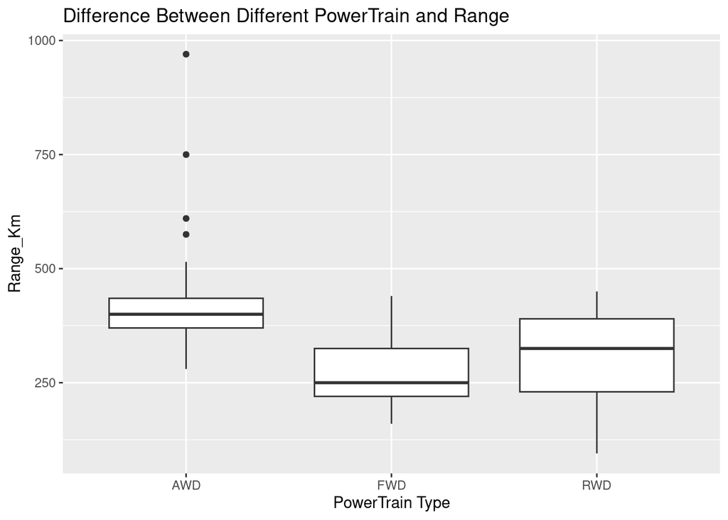

```r
ggplot(df, aes(PowerTrain, Range_Km))+geom_boxplot()+labs(title = "Difference Between Different PowerTrain and Range", x="PowerTrain Type", y="Range_Km") # plots for showing the difference between power train and range
```

EV’s with AWD PowerTrain are the best performer in Range, then FWD, last RWD. It was determined by the minimum range Km the electric vehicle can drove.

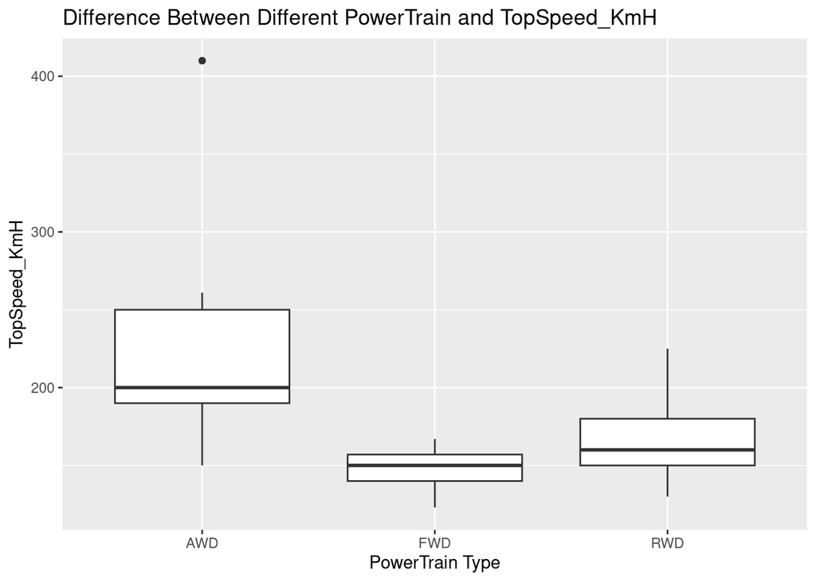

```r
ggplot(df, aes(PowerTrain, TopSpeed_KmH))+geom_boxplot()+labs(title = "Difference Between Different PowerTrain and TopSpeed_KmH", x="PowerTrain Type", y="TopSpeed_KmH") # plots for showing the difference between power train and top speed
```

EV’s with AWD PowerTrain are the best performer in Top Speed, then RWD, last FWD. It was determined by the minimum top speed Km per hour.

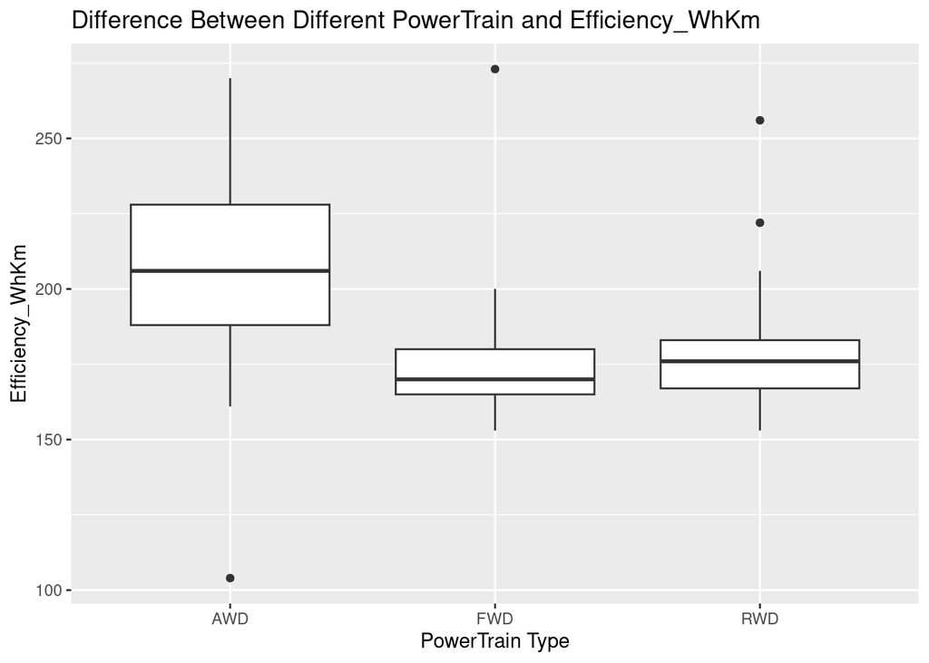

```r
ggplot(df, aes(PowerTrain, Efficiency_WhKm))+geom_boxplot()+labs(title = "Difference Between Different PowerTrain and Efficiency_WhKm", x="PowerTrain Type", y="Efficiency_WhKm") # plots for showing the difference between power train and efficiency
```

EV’s with AWD PowerTrain are the best performer in Efficiency, then RWD, last FWD. It was determined by the average efficiency_WhKm.

A3: Overall, EV’s with AWD PowerTrain will have better performance in range, speed, and efficiency.

Solving Q4: Which Manufacturer has the most number of vehicles? My thoughts: Using sqldf for counting vehicles in each brand

```r
sqldf("SELECT DISTINCT Brand, COUNT(Brand) as num_vehicels FROM df GROUP BY Brand")
```

```
##          Brand num_vehicels
## 1      Aiways             1
## 2        Audi             9
## 3         BMW             4
## 4       Byton             3
## 5       CUPRA             1
## 6     Citroen             1
## 7          DS             1
## 8        Fiat             2
## 9        Ford             4
## 10      Honda             2
## 11    Hyundai             3
## 12     Jaguar             1
## 13        Kia             5
## 14      Lexus             1
```

[output cut: 19 more lines]

A4: Tesla has the most number of vehicles.

Solving Q5: How does price related to rapid charging My thoughts: Using ggplot to show the distribution between price and rapid charging

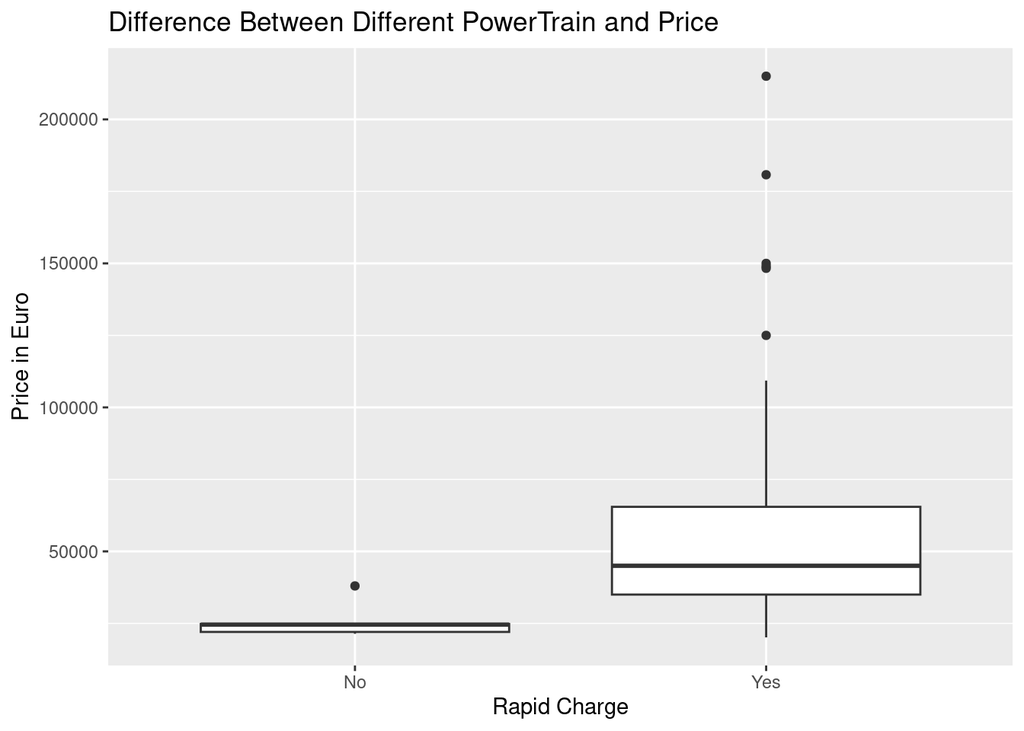

```r
ggplot(df, aes(RapidCharge, PriceEuro))+geom_boxplot()+labs(title = "Difference Between Different PowerTrain and Price", x="Rapid Charge", y="Price in Euro") # plots for showing the difference between power train and efficiency
```

That’s the end of all questions. Thanks you for reading my project in R.